# SPS 506 · Class 5

## Performance Measurement

SPS 506 · Public Program Evaluation · September 24, 2026

Performance  
Measurement

## Phoenix, 2014: the VA wait-time scandal

Feb 2014A longtime Phoenix VA doctor alleges that 40 veterans died waiting for appointments, and that the hospital kept secret wait lists

May 2014The Inspector General confirms serious scheduling problems. VA Secretary Eric Shinseki resigns

Aug 2014Congress passes the Veterans Choice Act, letting veterans who face long waits get care outside the VA

[figure not shown]

March 2015: President Obama and VA Secretary Robert McDonald meet with veterans at the Phoenix VA. Official White House photo by Pete Souza (public domain)

CNN · April 23, 2014“A fatal wait: Veterans languish and die on a VA hospital’s secret list”

NBC News · August 26, 2014“VA: No Proof Delayed Medical Care Caused Deaths in Phoenix”

VA OIG, Report 14-02603-178 (May 28, 2014); Public Law 113-146 (Aug. 7, 2014); final OIG report 14-02603-267 (Aug. 26, 2014)

## What the Phoenix VA reported, and what the Inspector General found

New patients, first primary care appointment, FY 2013

**24 days**Average wait in the VA’s national data, as reported by Phoenix

**115 days**Average wait the Inspector General found for the same 226 veterans

The goal was 14 days. Wait times counted toward managers’ awards and raises.

VA Office of Inspector General, Report 14-02603-178, May 28, 2014, pp. iii, 3

## At Phoenix, a veteran’s wait didn’t count until they were booked or put on the official list

Behind the “secret wait lists”

**1,700**veterans waiting for primary care who were not on the official electronic wait list, April 2014

**~1,100**on a report of new enrollees who had asked for an appointment

**~400**on paper printouts of calls to the helpline

**~200**on referrals to primary care still pending

“The length of time these 1,700 veterans wait for appointments prior to being scheduled or added to the [wait list] *will never be captured in any VA wait time data* because [Phoenix VA] staff had not yet scheduled their appointment or added them to the [wait list].” VA Office of Inspector General, interim report on Phoenix, May 28, 2014, p. 1

Counts and sources of the 1,700: same report, p. 1. “Secret wait lists”: p. iii

Was the problem the people, or the measure?

## Why measure

Part 1

Why measure?

The promise, the skeptics, and eight purposes

## The performance movement was premised on the idea that measuring results would change what government rewards

The promise

“If you can’t see success, you can’t reward it … If you can’t reward success, you’re probably rewarding failure.”

Osborne and Gaebler (1992), *Reinventing Government*, ch. 5

The skeptic

“‘Performance’ has joined motherhood and apple pie as one of the truisms of the contemporary American culture. Who would want to say that they are against performance assessment?”

Radin (2006), *Challenging the Performance Movement*, p. 4

## Different purposes require different measures

**Evaluate**How well is my agency performing?

**Control**Are my people doing the right thing?

**Budget**Where should the money go?

**Motivate**How do I get people to improve?

**Promote**How do I show stakeholders we do a good job?

**Celebrate**What is worth celebrating?

**Learn**Why is what working, or not?

**Improve**What exactly should who do differently?

One VA wait-time number had to evaluate, control, and motivate managers through awards. Which job broke it?

Behn, R. D. (2003). Why measure performance? Different purposes require different measures. *Public Administration Review*, 63(5), 586–606.

## Measurement tells you what happened. Evaluation tells you why.

Performance measurement“Ongoing monitoring and reporting of program accomplishments, particularly progress toward pre-established goals”CDC (2024), p. 3

Program evaluation“Uses systematic data collection and analysis of programs, policies, and organizations to assess their effectiveness and efficiency”CDC (2024), p. 1

“Although ongoing monitoring systems track what is in fact occurring with respect to program outputs and outcomes, on their own they cannot address the **‘how’ and ‘why’** questions about how programs produce desired outcomes.” Poister, Handbook ch. 5, p. 109

## The numbers say your program is failing. What happens to its budget?

Poor performance

**Cut it**It’s wasting money. Stop rewarding failure.

**Fund it more**It’s underfunded, or too important to fail. Nobody slashes the Border Patrol because the border isn’t sealed.

“If a program performs poorly, does that mean it should be cut because it is wasting money or increased so that it can do better?” Gilmour and Lewis (2006), *Public Administration Review*, p. 743

Ho (2003), pp. 166–167: the one place Iowa officials doubted performance measurement was in setting funding priorities

## CDC’s 2024 framework treats performance data as an input to evaluation, not a substitute

1Assess context

2Describe the program

3Focus the evaluation questions and design

4Gather credible evidencePerformance data enter here

5Generate and support conclusions

6Act on findings

“Interest holders might have extensive experience with performance measurement … and incorrectly interpret this activity as synonymous with program evaluation.” (p. 10)

CDC Program Evaluation Framework, 2024. *MMWR Recommendations and Reports*, 73(6), pp. 3–5, 10

## What to measure

Part 2

What to measure

How would you know a program is working?

## Last week: Idaho LAUNCH logic model

Scholarships for high school seniors · Problem statement: a lack of skilled workers in Idaho

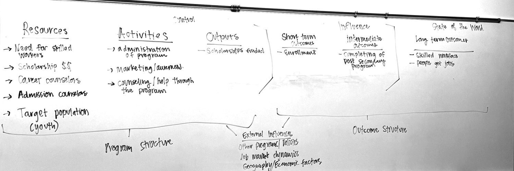

What would you count to know each part is working?

## Every box in your LAUNCH model is a place to put a measure

Control

Influence

State of the world

**Resources**Scholarship $$, counselors

**Activities**Marketing, counseling

**Outputs**Scholarships funded

**Short-term**Enrollment

**Intermediate**Completing a program

**Long-term**Skilled workforce, people get jobs

**Inputs**Dollars awarded, counselor hours

**Service quality**Days from application to award

**Output**Scholarships awarded

**Outcome**% of recipients who enroll

**Outcome**% who finish a credential

**Outcome**% working in Idaho in an in-demand job

**Efficiency** = outputs ÷ resources: cost per scholarship awarded

**Cost-effectiveness** = outcomes ÷ resources: cost per recipient who finishes

The further right the measure, the less the program controls it, and the more you need an evaluation to say the program caused it.

Logic model: class 4 group activity. Measure types: Handbook ch. 5, pp. 110–113

## Output, outcome, efficiency, or quality?

Miles of guardrail replaced

Output

Highway accidents, injuries, and fatalities per 100,000 vehicle miles

Outcome

Cost per ton of residential refuse collected

Efficiency

Child-support calls returned within 24 hours

Quality

Crisis-stabilization clients back in crisis within 30 days

Outcome

AIDS seminars presented

Output

All examples from Handbook ch. 5, pp. 110–112

## When measures fail

Part 3

When measures fail

What went wrong in Phoenix is a pattern, not an accident

## People perform toward the measure and sacrifice the goal

**Goal displacement**Push transit drivers on schedule adherence and you may get *reckless driving*. NCLB brought *teaching to the test* and narrowed curricula.

**Cream-skimming**Serve the easy cases first. Disability offices could *“pick and choose which files to do to meet target.”*

**What isn’t counted**Access, equity, and due process are hard to quantify, so they *drop out* of the scorecard.

**Political weapon**Numbers can be *used against* the people who report them, especially in an election year.

Handbook ch. 5, p. 118 and Table 5.1, p. 120; Ho (2003)

## Officials in cities that don’t report were about twice as likely to worry about political misuse

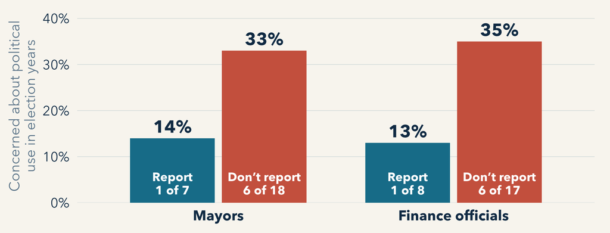

Ho (2003), Table 5, p. 170. Iowa cities of 10,000–100,000. Small samples: mayors 7 reporting / 18 not; finance officials 8 / 17.

## What makes a good measure: Phoenix’s wait measure passed the easy tests and failed the ones that mattered

A good measure is …

The VA’s 14-day wait measure

Valid and reliable

**No.** The clock started when staff booked, not when the veteran asked

Meaningful and understandable

Yes. Every veteran understands a wait

Balanced and comprehensive

**No.** One number, and it only saw veterans who made the list

Timely and actionable

Yes. Reported routinely up the chain

Resistant to goal displacement

**No.** Tied to awards, so it was worth gaming

Practical and not too costly

Yes. Pulled automatically from the scheduling system

Criteria: Handbook ch. 5, pp. 116–119. VA details: OIG Report 14-02603-178, pp. ii–4

## One number invites gaming. A balanced scorecard makes it harder to chase just one.

**Customer**How do the people we serve see us?Satisfaction, access, timeliness

**Internal processes**What must we excel at?The operations that make customer results possible

**Innovation and learning**Can we keep improving?Staff skills, systems, new practices

**Financial**How do we look to Congress, the governor, the council?Cost, efficiency, results for the money

Kaplan and Norton (1992); Handbook ch. 5, p. 115: scorecards focus on the organization, logic models on the program

## Activity: A balanced scorecard for ITD

Work in groups

1The Treasure Valley’s growth has brought congestion. The governor wants ITD’s goals aligned from division managers down

2Write two performance measures for each of the four perspectives Customer · internal processes · innovation and learning · financial

3Label each one: output, outcome, efficiency, quality, or satisfaction

4Pick the measure most likely to be gamed. How would someone game it? Then add one measure that would catch it

## Measures tell you what happened, not why

24 days reported · 115 days waited

A measure tells you *what* happened, not *why*. And whatever you measure, people will chase.

## Before we leave

**Next week**

Research design and data collection I: Handbook ch. 4, 13, and 17. Case: Team Read (A)

**Logic model and stakeholder analysis**

Due October 8, by class time

For your program: name one output measure and one outcome measure. How could someone game the outcome?